# ØMQ

25/03/2015

## Introducción

## El problema

> Connect your code in any language on any platform  
> Pieter Hintjens, ØMQ lead maintainer.
- Conectar código (en **cualquier lenguaje**) con otro código (en **cualquier lenguaje**), sobre cualquier plataforma y en cualquier lugar.
- Implementar una solución con **componentes sencillos**, fácil de utilizar.
- Comunicación **asíncrona** y de **alta velocidad**.

## ØMQ (a.k.a. ZeroMQ, ZMQ)

- **Entorno de concurrencia** (pero parece biblioteca de comunicación por red).
- **Mensajes atómicos**, varios **modos de transporte** (proceso, entre procesos, TCP, multicast).
- Basado en **sockets**, conexión N a N.
- **Patrones**: fan-out, pub-sub, req-rep, router, etc.
- **Muy rápido** (concebido originalmente para negociación bursátil).
- E/S **asíncrona** (escalabilidad).
- APIs en **más de 30 lenguajes** de programación.
- Software libre (LGPLv3).

## Algunos usuarios

- AT&T.
- Cisco.
- EA.
- NASA, CERN.
- Zynga.
- Spotify.
- Microsoft.

## Aspectos básicos

- Minimalismo:
  - "Zero broker".
  - "Zero administration".
  - "Zero cost".
  - "Zero waste".

Entremos en materia…

## Mensajería en 3 pasos

## Sistema de mensajería con ØMQ

1. Elegimos un protocolo (modo) de **transporte**.
2. Escoger componentes de la **infraestructura**.
3. Definir un **esquema** de comunicación.

## Modos de transporte

1. Comunicación en el proceso (*in-process communication*).

   ```python
   inproc://#1
   inproc://my-endpoint
   ```

2. Comunicación entre procesos (*IPC*).

   ```python
   ipc:///tmp/feeds/0
   ```

3. Protocolos de red: TCP o IP Multicast (PGM o EPGM).

   ```python
   tcp://127.0.0.1:30000
   pgm://192.168.1.1;239.192.1.1:5555
   ```

## Componentes

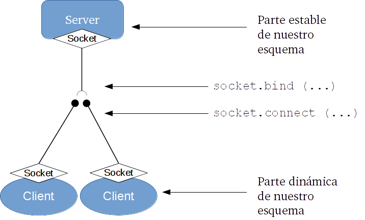

## Esquemas de comunicación

- Resueltos mediante **patrones de diseño**.
  - Request/Response (cliente-servidor).
  - Publish/Subscribe.
  - Pipelining (transferencia de datos).
  - Exclusive pair (1:1).
- **Devices** (conexión agentes dinámicos).

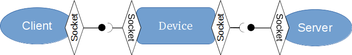

## Hello world (cliente-servidor)

## Hello world: server

```python
# Hello World server in Python
# Connects REQ socket to tcp://localhost:30000
# Sends "Hello" to server, expects "World" back
#
# Import python bindings (pyzmq)
import zmq
# Get context (only once!)
context = zmq.Context()
socket_rep = context.socket(zmq.REP)
# Server is bound to a port
socket_rep.bind("tcp://127.0.0.1:30000")
# Using built-in JSON serialization (pyzmq)
message = socket_rep.recv_json()
print "Received message: %s" % message
print 'Sending "world"'
socket_rep.send_json("world")
```

## Hello world: client

```python
# Hello World client in Python
# Connects REQ socket to tcp://localhost:30000
# Sends "Hello" to server, expects "World" back
#
# Import python bindings (pyzmq)
import zmq
# Get context (only once!)
context = zmq.Context()
socket_req = context.socket(zmq.REQ)
# Client connects to port
socket_req.connect("tcp://127.0.0.1:30000")
# Using built-in JSON serialization (pyzmq)
socket_req.send_json("Hello")
print "This is a blocking call..."
message = socket_req.recv_json()
print "Received message: %s" % message
```

## Patrones de diseño

## Request-Reply

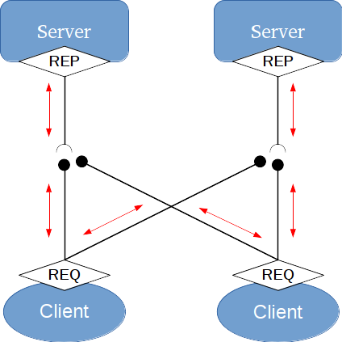

## Request-Reply (reparto de carga)

- `class zmq.devices.Proxy(in_type, out_type, mon_type=1)`

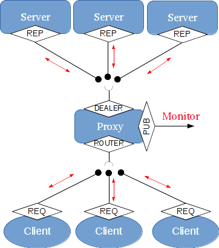

## Publisher-Subscriber

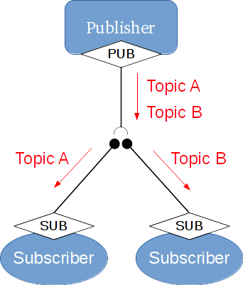

```python
# Publisher
import zmq
from random import choice
context = zmq.Context()
socket = context.socket(zmq.PUB)
socket.bind("tcp://127.0.0.1:30000")
teams = ['ATL','BAR','MAD','VAL']
events = ['YCAR', 'RCARD', 'GOAL',
          'CORNER', 'FOUL', 'PENALTY']
while True:
    msg = "%s %s".format(choice(countries),
                         choice(events))
    print "Published: ",msg
    socket.send(msg)
# Subscribers
import zmq
context = zmq.Context()
socket = context.socket(zmq.SUB)
socket.connect("tcp://127.0.0.1:30000")
socket.setsockopt(zmq.SUBSCRIBE, "BAR")
socket.setsockopt(zmq.SUBSCRIBE, "ATL")
while True:
    print  socket.recv()
```

## Pipelining

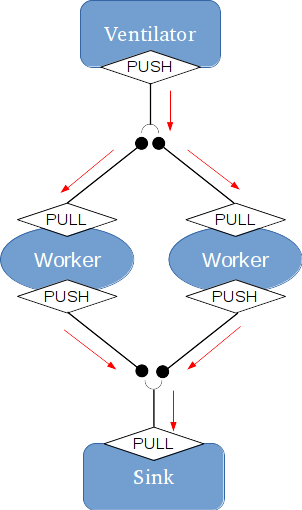

```python
# Ventilator
import zmq
context = zmq.Context()
socket = context.socket(zmq.PUSH)
socket.bind("tcp://127.0.0.1:30000")
while True:
      socket.send(data_chunk)
# Worker
import zmq
context = zmq.Context()
socket_up = context.socket(zmq.PULL)
socket_down = context.socket(zmq.PUSH)
socket_up.connect("tcp://127.0.0.1:30000")
socket_down.connect("tcp://127.0.0.1:30001")
while True:
    data_chunk = socket_up.recv()
    # Proces data chunk --> data result
    socket_down.send(data_result)
# Sink
import zmq
context = zmq.Context()
socket = context.socket(zmq.PULL)
socket.bind("tcp://127.0.0.1:30001")
while True:
      data_result = socket.recv()
```

## Exclusive-pair

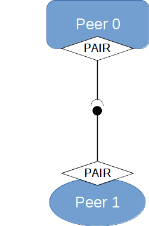

```python
# Peer 0 (Parent process)
import zmq
context = zmq.Context()
socket = context.socket(zmq.PAIR)
socket.bind("ipc:///tmp/pipes/zmq0")
# Do something else, wait for child process
socket.recv() # Blocking
print("Test successful!")
#
# Peer 1 (Child process)
import zmq
context = zmq.Context()
socket = context.socket(zmq.PAIR)
socket.connect("ipc:///tmp/pipes/zmq0")
# Do something, eventually warn parent process
sender.send(b"")
```

## Serialización

- Serialización en `pyzmq`.
  - `send_json() # With json module`
  - `send_pyobj() # With pickle module`
- Ejemplo de personalización:

```python
import ujson, zlib
def send_ujson(socket, obj, flags=0):
    """Serialize object using ultra-fast ujson"""
    m = ujson.dumps(obj), z = zlib.compress(m)
    return socket.send(z, flags=flags)

def recv_ujson(socket, flags=0):
    """Load object from ujson serialization"""
    z = socket.recv(flags), m = zlib.decompress(z)
    return ujson.loads(m)
```

## Características adicionales

- Muchos **más patrones** de diseño.
  - Balanceo de carga en clusters.
  - Pipelining con control de cierre.
  - Pub/sub de alta disponibilidad.
  - etc.
- Desde la versión 4.0.0, se incluye **framework de seguridad**.
  - NULL.
  - PLAIN.
  - CURVE.

## Referencias

- ØMQ. Code connected (project page). http://zeromq.org/.
  - Learn the basics http://zeromq.org/intro:read-the-manual.
  - The guide http://zguide.zeromq.org/page:all.
  - Pieter Hintjens. *ZeroMQ. Messaging for Many Applications*. O'Reilly Media. March 2013.
- Nicolas Piël. *ZeroMQ: An introduction*. http://nichol.as/zeromq-an-introduction.
- Pyzqm (documentation). http://zeromq.github.io/pyzmq/.

## Contacto

- **Felipe Ortega**.
  - Dpto. Informática y Estadística, Universidad Rey Juan Carlos.
  - E-mail: felipe.ortega@urjc.es
  - Twitter: @jfelipe
  - Web: http://felipeortega.net

[figure not shown]